# BUA 455 - Week 2: Intro dplyr & ggplot

### Showing Plots in A 2x2 Grid

- Another common presentation task is to show a grid, row, or column of plots.
- Final plot is simplified for showing in the 2x2 grid

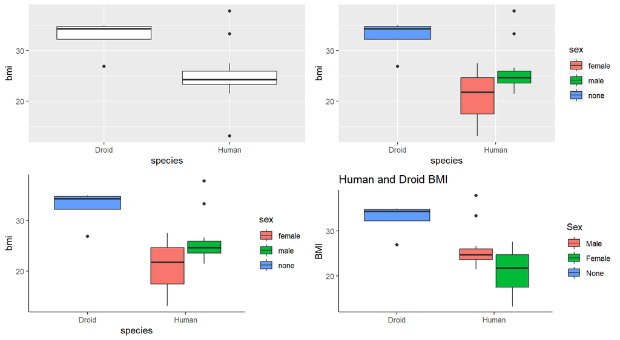

```r
(sw_grid <- grid.arrange(sw_box1, sw_box2, sw_box3, sw_box4_grid, ncol=2))   #2x2 grid of plots
```

### Exporting a Plot: Two Methods

**Method 1:**

1. Right click on plot on right
2. Select ‘Save image as…’
3. Save image as .png file (or other preference)

*Notes*

- This method is very quick and is great for saving one plot at a time.
- Ideally work should be saved to your `code_data_output` folder.

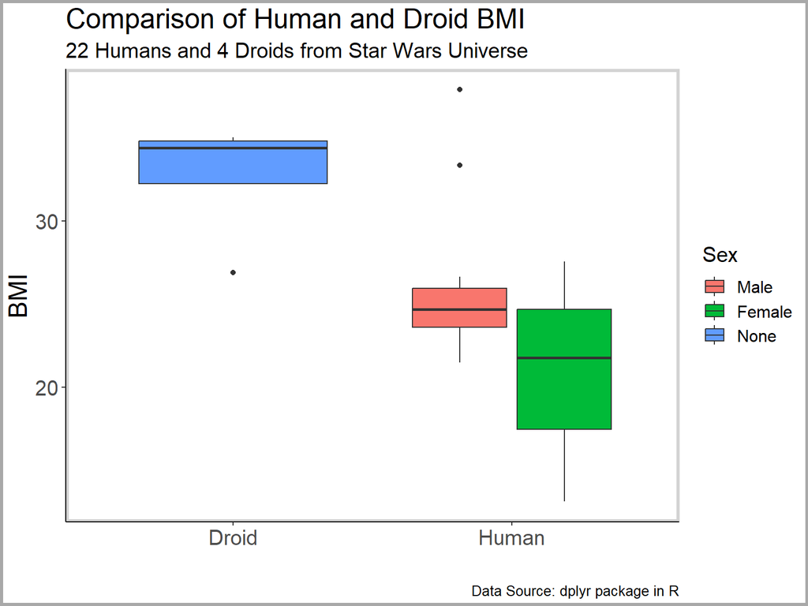

**Method 2:**

- Use `ggsave` command
- Defaults to last plot displayed
- Below I override the default to specify plot I want.

```r
ggsave("StarWars_BMI_Boxplot.png",
       plot=sw_box4, width = 8, height = 6)
```

### Creating a README File

**in HW 2 you will:**

- Create and modify an R Markdown file
- Knit R Markdown file to create an HTML file
- Create a README file

**A README file documents all files in your R project**

- README files can be simple or complex.
- BUA 455 will use one README file format
  - [Empty README file template](https://drive.google.com/file/d/1lsqpffL5b5XsTSrV7VKfWeYIDxoH1PZS/view?usp=sharing)
  - [Completed README file for Week 2 lectures](https://drive.google.com/file/d/1Q_vzUumn_ojAjNoATedtu4J78_fILwPs/view?usp=drive_link)

**Editing a README.txt file**

- in RStudio: File > Open File > click on file
- in *Notepad* (Windows OS) or *TextEdit* (Mac OS)

### Week 2 In-class Exercises (L3 - Q3 & Q4)

*Session ID: bua455f24*

**`Q3.`** What type of file is the README file?

**`Q4.`** We will use the `pacman` R package, in every lecture, and assignment because it simplifies installing a loading other packages.

There is another package (actually it’s a package suite that includes both `dplyr` and `ggplot2`) that we will will we use in every lecture, assignment, and quiz in BUA 455.

The name of this package suite is `____`.

### Introduction to HW 2

**In class we will work through HW 2 Instructions**

Students are encouraged but not required to *work with a partner* at least once for HW2, HW 3, or HW 4).

- All students are responsible for understanding **all** coding
- Working with a partner at least once will help during group project.

**Easy Collaboration for now:**

- Each student makes their own R project and internal `code_data_output` folder for HW 2.
- Email or share .Rmd file in a cloud drive

**[Posit Cloud](https://posit.cloud/)** allows for “google-drive” style collaboration on an R project with 5 people ($5/month).

**GitHub** used for collaboration and version control in more advanced courses and other disciplines (Not required in this course).

### HW 2 Purpose

**HW Assignment 2** will give you experience with:

- Creating an R Project Directory and a code_data_output folder (Review)
- Creating, saving, using an R Markdown file (Review)
- Knitting (rendering) an R Markdown file to create an HTML file
- Creating a README file
- Working with a larger dataset
- Using the **`dplyr`** package to **`select`** variables and **`slice`** and **`filter`** data
- Creating a basic plot with minimal formatting

You are encouraged to work with someone on HW 2, HW 3, or HW 4.

- Practice sharing files with a partner.

### HW 2 - First Steps

**`0.`** You are encouraged to work with others and and experiment with sharing code (.Rmd files), but each student should create their own project and .Rmd file to submit.

**`2.`** Create a folder in your R project labeled **`code_data_output`**.

**`3.`** Download the provided file, **`HW2_Template.Rmd`**

**`4.`** Save the downloaded **`HW2_Template.Rmd`** file to your code_data_output folder

- Change file name to be **`HW2_FirstName_LastName.Rmd`**
  - For example, I would change the template file to be named **`HW2_Penelope_Pooler.Rmd`**
- Change title in the file header to be ‘HW 2’
- Specify yourself as the author

**NOTES**

- Provided header text below shows the correct format.
- This header text also creates a floating Table of Contents (toc).

```
---
title: "HW 2"
authors: "Penelope Pooler"
date: "Due 1/31/2024"
output:
  html_document:
    toc: true
    toc_depth: 4
    toc_float: true
---
```

**`5.`** Modify the **`setup`** chunk

- The **`setup`** chunk text shown below has packages and setup options for HW 2.
- Copy and paste text into the setup chunk of your HW 2 Markdown (**`.Rmd`**) file that you created from the provided template.

```
# this line specifies options for default options for all R Chunks
knitr::opts_chunk$set(echo=T, highlight=T)

# suppress scientific notation
options(scipen=100)

# install helper package (pacman) if needed
if (!require("pacman")) install.packages("pacman", repos = "http://lib.stat.cmu.edu/R/CRAN/")

# install and load required packages
# pacman should be first package in parentheses and then list others
pacman::p_load(pacman, tidyverse, gridExtra, magrittr)

# verify packages (comment out in finished documents)
p_loaded()
```

**`6.`** Click the green triangle or type Ctrl/Cmd + Shift + Enter to run this setup chunk.

### HW 2 - Part 1

#### Chunk 2: Examining the `diamonds` Data

#### Notes

- This chunk reviews the **`glimpse`** and **`unique`** commands from Week 1.
- **`diamonds`** is large dataset that is part of the **`ggplot2`** package in the tidyverse suite.
- Provided code for HW 2 - Part 1 (Chunk 2) **will not run** until the **`tidyverse`** package suite is loaded in the **`setup`** chunk.
- When you run the **`glimpse()`** command you will see the variable type *`<ord>`*, which is an **ordered factor variable**.

#### Steps to Follow

**`1.`** Run the R code in the provided R chunk for HW 2 - Part 1 (Chunk 2) which reviews:

- how to save a dataset and examine it using **`glimpse`**
- how to examine the levels of a variable using **`unique`**
- traditional and piped code to do the same task

**`2.`** Use the **`unique`** command with or without piping to examine the levels of:

- the **`clarity`** variable
- the **`color`** variable
- The new **`unique`** commands that you write should be **ADDED** to Chunk 2.

**`3.`** Answer Blackboard Questions 1 - 3.

#### Provided R Code

```
# save the diamonds dataset to your Global Environment
my_diamonds <- diamonds

# show data summary
# without piping
glimpse(my_diamonds)

# with piping
my_diamonds |> glimpse()

# examine ordinal variables using unique
# without piping
unique(my_diamonds$cut)

# with piping
# pull command selects a single variable from a dataset
my_diamonds |> pull(cut) |> unique()

# choose one of these methods to examine:

# ordered levels of clarity

# ordered levels of color
```

### Week 2 In-class Exercises (L4 - Q1)

*Session ID: bua455f24*

**This is also BB Question 1 of HW 2**

How many rows and columns are in the `diamonds` dataset that is saved as `my_diamonds` to your Global Environment?

- `____` observations (rows)
- `____` variables (columns)

### Week 2 In-class Exercises (L4 - Q2)

*Session ID: bua455f24*

How many variables in the `my_diamonds` dataset are ordinal (ordered) factor variables?

- In the `glimpse(my_diamonds)` output, these variables are labeled *`<ord>`*.

### HW 2 - Part 2

#### Chunk 3: Selecting variables in a dataset

#### Notes

- This chunk demonstrates using the **`select`** command to select variables in a dataset.
- In the provided code for HW 2 - Part 2 (Chunk 3),there are **three code examples** that select the first 7 variables in the my_diamonds dataset and save them as a new data set.
  - **`my_diamonds1`** is created by specifying variables to **INCLUDE**
  - **`my_diamonds2`** is created by specifying variables to **EXCLUDE**
  - **`select`** is ALSO used to reorder the variables (**`price`** is first)

#### Steps to Follow

**`1.`** Create **`my_diamonds3`** using the select command to only **INCLUDE** the first **FIVE** variables:

- **price, carat, cut, color, clarity**

**`2.`** Create my_diamonds4 which will be identical to my_diamonds3, but is created by **EXCLUDING** the last FIVE variables using the **`!`** operator and the **`c(...)`** operator to group the variables:

- **depth, table, x, y, z**

#### Provided R Code

```r
# creates a new dataset, my_diamonds1
# selects variables we want to keep
# select can also re-order variables (price is now first)
my_diamonds1 <- my_diamonds |>
  select(price, carat, cut, color, clarity, depth, table)

# same command, but shorter
# used : to specify consecutive variables
my_diamonds1 <- my_diamonds |>
  select(price, carat:table)

# creates a new dataset, my_diamonds2
# identical to above but we use ! to exclude variables
my_diamonds2 <- my_diamonds |>
  select(!c(x,y,z))

# create my_diamonds3 using select to keep these variables only:
# price, carat, color, cut, clarity

# create my_diamonds4 using select to EXCLUDE these variables
# depth, table, x, y, z
```

### HW 2 - Part 3

#### Chunk 4: Selecting rows by row number

#### Notes

- This chunk demonstrates using the **`slice`** command to select observations (rows).
- In the provided code for HW 2 - Part 3 (Chunk 4), and subsequent chunks you will continue to build on your code from Part 2 (Chunk 3) with more commands.
- Using piping in your code makes this process more efficient.

#### Steps to Follow

**`1.`** Copy and the code you wrote to create **`my_diamonds3`** in Chunk 3 and paste this code into Chunk 4.

**`2.`** Use the examples to add on to your code and select rows: 1001 through 30000 and 45001 through 50000

- This dataset should still be named **`my_diamonds3`**
- Piping will make your coding more efficient and easier to read.

**`3.`** Answer Blackboard Question 4 to verify that your dataset is correct.

#### Provided R Code

```r
my_diamonds1 <- my_diamonds |>
  select(price, carat, cut, color, clarity, depth, table) |>
  slice(5001:35000)

my_diamonds2 <- my_diamonds |>
  select(price, carat:table) |>
  slice(1, 200, 2301:3000, 29000:32000)

# Use the code from Chunk 3  that you wrote to create my_diamonds3
# add on to that code to limit my_diamonds3 to rows:
# 1001 through 30000 and 45001 through 50000
```

### HW 2 - Part 4

#### Chunk 5: Filtering data by value and summarizing

#### Notes

- This chunk demonstrates
  - using the **`filter`** command to select rows by variables values
  - using the **`summary`** command
- The **`filter`** command enables us to select observations by one or more values of one or more variables.
- You can use multiple consecutive **`filter`** commands or you can use the **and** operator, **`&`**, or the **or** operator, **`|`**.
- You can use filter to **INCLUDE** rows or **EXCLUDE** rows with **`!`**.
- The provided code includes multiple examples of how to complete the same two filtering tasks.

#### Steps to Follow

**`1.`** Copy the code you wrote in Chunk 4 and then paste it into Chunk 5.

**`2.`** Add the specified slice command to subset the **`my_diamonds3`** dataset in Chunk 5.

**`4.`** Use the example **`summary`** command code to summarize the factor variable **`clarity`** in the final **`my_diamonds3`** dataset.

**`5.`** Answer Blackboard Questions 5 and 6 to verify that you have completed these steps correctly.

#### Provided R Code

```
# filtering my_diamonds1 to
# carat weight greater than or equal to 2 (carat >=2)
# cut is Premium or Ideal (cut %in% c("Premium", "Ideal"))
my_diamonds1 <- my_diamonds |>
  select(price, carat:table) |>
  slice(5001:35000) |>
  filter(carat >= 2) |>
  filter(cut %in% c("Premium", "Ideal"))

# same filtering tasks as above
# !cut used to exclude cuts Fair, Good, Very Good
my_diamonds1 <- my_diamonds |>
  select(price, carat:table) |>
  slice(5001:35000) |>
  filter(carat >= 2) |>
  filter(!cut %in% c("Fair", "Good", "Very Good"))

# same filtering tasks as above
# both filtering tasks combined using and operator &
my_diamonds1 <- my_diamonds |>
  select(price, carat:table) |>
  slice(5001:35000) |>
  filter(carat >= 2 & cut %in% c("Premium", "Ideal"))

# summary of color in my_diamonds1
summary(my_diamonds1$color)

# same summary with piping
my_diamonds1 |> pull(color) |> summary()

# Use any one of the examples above to filter my_diamonds3 to:
# carat weight greater than or equal to 1.25
# cut is Very Good, Premium, or Ideal


# summarize clarity in the my_diamonds3 dataset (number of obs. in each level)
# use the summary command, with or without piping
# above I show how I summarized the color variable
```

### HW 2 - Part 5

#### Chunk 6: Creating Basic Plots

#### Notes

- The provided R code demonstrates using
  - **`ggplot`** to make some basic plots
  - **`grid.arrange`** to present multiple plots in a grid or column.
- In Part 5, you will create a chunk and copy the provided R code into the chunk you create.

#### Steps to Follow

**`1.`** Create a new chunk (Chunk 6) under the **HW 2 - Part 5** heading in your HW 2 Markdown file.

- Name this new chunk **`creating plots with ggplot`**

**`2.`** Copy and paste the provided R code below into the chunk you created.

**`3.`** Use the example scatter plot code below to create a saved plot named **`scatter_cut`**.

- This will be similar to the code for the **`scatter_clarity`** scatter plot.
- Remove **`#`** at the beginning of this line **`# scatter_cut <-`** to start code.
- Replace **`color=clarity`** with **`color=cut`**.

**`4.`** Use the example code provided below to create a saved plot named **`scatter_color`**.

- This will be similar to the code for the **`scatter_clarity`** scatter plot.
- Remove **`#`** at the beginning of this line **`# scatter_color <-`** to start code.
- Replace **`color=clarity`** with **`color=color`**.

**`5.`** Use the provided **`grid.arrange`** command to create a 2x2 grid of all four scatter plots.

- Remove **`#`** at the beginning of the line with **`grid.arrange(..., ncol=2)`**
- This code will only work if you use the provided names to save your scatterplots.

**`6.`** Use the provided example boxplot code below to create a saved plot named **`box_clarity`**

- This will be similar to the provided code for the side-by-side grouped boxplot, **`box_color`**.

**`7.`** Use the provided **`grid.arrange`** command to create a stacked column of the two boxplot figures.

- Remove **`#`** at the beginning of the line with **`grid.arrange(..., ncol=1)`**
- This code will only work if you use the provided name to save your new boxplot figure.

**`8.`** Answer Blackboard Questions 7 and 8 based on the plots you create.

#### Provided Scatter Plots R code

```r
# scatter_none is the most basic scatter plot of carat vs. price
# no other variables are included
# to view this plot by itself (not required), enclose code in parentheses
scatter_none <- my_diamonds |>
   ggplot() +
   geom_point(aes(x=carat, y=price))

# scatter_clarity adds the option color=clarity to the aes (aesthetic)
# observations are color coded by diamond clarity level
# theme_classic() added to remove background
scatter_clarity <- my_diamonds |>
  ggplot() +
  geom_point(aes(x=carat, y=price, color=clarity)) +
  theme_classic()

# create plot named scatter_cut using the above code
# change color=clarity to color=cut
# scatter_cut <-

# create plot named scatter_color using the above code
# change color=clarity to color=color
# scatter_color <-

# plot all 4 plots above in a 2x2 grid and answer Blackboard Questions
# grid.arrange(scatter_none, scatter_clarity,
#              scatter_color, scatter_cut, ncol=2)
```

#### Provided Boxplots R code

```r
# below is a plot of grouped side-by_side boxplots
# Within each cut category there is a separate boxplot for each color
# this is one good way to examine categorical data

# code is enclosed in parentheses
# plot is saved as box_color AND is shown on the screen
(box_color <- my_diamonds3 |>
  ggplot() +
  geom_boxplot(aes(x=cut, y=price, fill=color))+
  theme_classic())


# create a plot of grouped side-by_side boxplots that show
# boxplots for each clarity category with each cut category

# same plot as above but change fill=color to fill=clarity

# name this plot box_clarity
# (box_clarity <- )


# plot these two sets of plots in a stacked column (nrow=1)
# grid.arrange(box_color, box_clarity, ncol=1)
```

### HW 2 - Final Steps

**Reminder:** You are welcome and encouraged to work together and practice sharing Markdown (`Rmd`) files, but each student should submit their own zipped R project and Blackboard assignment.

**`1.`** Save your completed HW 2 R Markdown File (.Rmd) to your code_data_output folder

**`2.`** Knit your R markdown File.

**`3.`** Answer all 8 Blackboard questions associated with this assignment.

**`4.`** Create a README file for HW 2 using the [empty README template](https://drive.google.com/file/d/1RlJkuJWRsaqy7KWo718bNTl570T8n_hi/view?usp=sharing) provided with the HW 2 files.

**`5.`** Zip your entire Project Directory into a compressed File and submit it.

- The zipped project directory should contain:
  - The `code_data_output` folder with 2 files in it:
    - the completed Markdown file (`.Rmd`)
    - the knitted (rendered) HTML file (`.html`)
  - In addition to the `code_data_output` folder, the outer project folder should ALSO include
    - The complete `README.txt` file saved with name of project, (e.g. `HW 2 Penelope Pooler README.txt`)
    - The .Rproj file

### **Key Points from Week 2**

**Building on R Project Skills:**

- Creating and Managing R Projects
- Creating, Editing, Rendering R Markdown Files
- Documenting files in a `README.txt` file

**Data Management and Visualization:**

- Review of
  - `glimpse`, `unique`, `table`, `summary`
- Modifying day using `dplyr commands:
  - `select`, `filter` `mutate`, `slice`
- Some Useful operators:
  - `!`, `%in%`, `c()`, `is.na`
- Intro to plotting data with `ggplot`

You may submit an ‘Engagement Question’ about each lecture until midnight on the day of the lecture. **A minimum of four submissions are required during the semester.**